# QIIME2 ↔︎ MaLiAmPi concordance

Genus-level tables of the Mexican preterm birth cohort, 110 specimens

Rendered 2026-10-01

**What this is.** The reproducible version of the comparison between the QIIME2/DADA2 and MaLiAmPi genus tables, ported from `analysis/as_run/gate_qiime2_maliampi_v3.R`. It has no absolute paths and no `setwd()`, fixes its random seed, checks the SHA-256 of every input before reading it, and ends with `sessionInfo()`. Question, design and verdict are in `docs/CONCORDANCE_QIIME2_MALIAMPI.md`.

**What it has to reproduce.** The outputs archived in `results/concordance/as_run_2026-09-21/`. The reproduction check at the end compares them number by number and file by file, and stops the render at the first difference.

**How to run it.** From the repository root:

```
Rscript -e "rmarkdown::render('analysis/concordance_qiime2_maliampi.Rmd')"
```

The three inputs are not in this repository (they are participant-level). By default they are looked for under the git-ignored `data/` and `metadata/` directories; if they live elsewhere, pass their location as parameters, e.g. `params = list(maliampi_out = "<MaLiAmPi output dir>", qiime2_dir = "<dir with level-6_vag138.xlsx>")`. Location does not matter: identity is established by hash. Tables and figures are written to `results/concordance/reproducible/`.

# 1 Setup

```r
suppressPackageStartupMessages({
  library(tidyverse)
  library(readxl)
  library(vegan)
  library(patchwork)
  library(ggrepel)
  library(scales)
})
# The project root is wherever this file sits under analysis/; no setwd().
suppressMessages(here::i_am("analysis/concordance_qiime2_maliampi.Rmd"))

SEED    <- 42   # set before each Mantel test; protest() continues the same stream
OUT_DIR <- here::here("results", "concordance", "reproducible")
AS_RUN  <- here::here("results", "concordance", "as_run_2026-09-21")
```

# 2 Inputs

Expected hashes come from `metadata/maliampi_outputs_manifest.csv` for the MaLiAmPi table and the specimen map, and from `docs/CONCORDANCE_QIIME2_MALIAMPI.md` §5 for the raw QIIME2 export. A mismatch stops the render.

```r
# A relative parameter is resolved against the project root; an absolute one is used as is.
resolve <- function(p) if (grepl("^(/|~|[A-Za-z]:[/\\\\])", p)) p else here::here(p)
sha256  <- function(p) digest::digest(p, algo = "sha256", file = TRUE)

manifest <- read_csv(here::here("metadata", "maliampi_outputs_manifest.csv"),
                     show_col_types = FALSE)
from_manifest <- function(rel) manifest$sha256[manifest$relative_path == rel]

inputs <- tibble(
  input    = c("MaLiAmPi genus tallies", "QIIME2 level-6 export", "Canonical specimen map"),
  file     = c("classify/tables/tallies_wide.genus.csv", "level-6_vag138.xlsx",
               "mapa_muestras_2026-09-20.csv"),
  path     = c(file.path(resolve(params$maliampi_out), "classify", "tables",
                         "tallies_wide.genus.csv"),
               file.path(resolve(params$qiime2_dir), "level-6_vag138.xlsx"),
               resolve(params$specimen_map)),
  expected = c(from_manifest("classify/tables/tallies_wide.genus.csv"),
               "2fe59049cc79c44cccf11b92e4eaae31990fa1431a84e6e4ab270d11d8ffbafe",
               from_manifest("metadata/mapa_muestras_2026-09-20.csv"))
)
stopifnot(all(nchar(inputs$expected) == 64))
if (!all(file.exists(inputs$path)))
  stop("Input not found: ", paste(inputs$file[!file.exists(inputs$path)], collapse = ", "),
       ". Set params maliampi_out, qiime2_dir or specimen_map to where it is.", call. = FALSE)
inputs$observed <- map_chr(inputs$path, sha256)

knitr::kable(transmute(inputs, input, file, sha256 = observed,
                       `matches record` = observed == expected))
```

| input | file | sha256 | matches record |
| --- | --- | --- | --- |
| MaLiAmPi genus tallies | classify/tables/tallies_wide.genus.csv | 2c7d208c295fb65e98c6fb4af5d35f0d5f015481ef63356288e2c4e1771974c6 | TRUE |
| QIIME2 level-6 export | level-6_vag138.xlsx | 2fe59049cc79c44cccf11b92e4eaae31990fa1431a84e6e4ab270d11d8ffbafe | TRUE |
| Canonical specimen map | mapa_muestras_2026-09-20.csv | 3b7e0b31ce6a8634c5951eeac4cf8223adfc8c3bfe00efc51293c272d5df4c91 | TRUE |

```r
stopifnot(identical(inputs$observed, inputs$expected))

PATH_MALIAMPI <- inputs$path[1]
PATH_QIIME2   <- inputs$path[2]
PATH_MAP      <- inputs$path[3]
```

# 3 Preparing the two tables

## 3.1 MaLiAmPi

`tallies_wide.genus.csv` has one row per taxon (any rank) and one column per specimen, named `Au###_S##`. The suffix is the sample-sheet position and is stripped to join. Composite names (`X/Y`) are excluded, as in v3.

```r
mal_raw <- read_csv(PATH_MALIAMPI, show_col_types = FALSE)
stopifnot(identical(dim(mal_raw), c(547L, 114L)))

# NCBI disambiguation suffixes, e.g. "Gordonia <high GC Gram+>" -> "Gordonia".
limpieza_ncbi <- function(x) str_trim(str_replace_all(x, "\\s*<[^>]*>", ""))

# solo_genero = TRUE keeps rank == "genus" (track genus); FALSE keeps every rank
# (track all_taxa). A name present at more than one rank is summed per specimen.
prep_mal_long <- function(mal_raw, solo_genero) {
  m <- mal_raw
  if (solo_genero) m <- m |> filter(rank == "genus")
  m <- m |> select(-any_of(c("tax_id", "rank")))
  m <- m[!str_detect(m$tax_name, "/"), , drop = FALSE]
  m |>
    pivot_longer(-tax_name, names_to = "sample_full", values_to = "count") |>
    mutate(count = replace_na(count, 0),
           sample_id = str_remove(sample_full, "_S\\d+$")) |>
    group_by(tax_name, sample_id) |>
    summarise(count = sum(count), .groups = "drop")
}

mal_specimens <- str_remove(setdiff(names(mal_raw), c("tax_name", "tax_id", "rank")),
                            "_S\\d+$")
stopifnot(length(mal_specimens) == 111, !anyDuplicated(mal_specimens))
table(rank = mal_raw$rank)
```

```
rank
         class         family        family_          genus          order
            34             84              1            338             44
        order_        order__         phylum          root_       subclass
             5              1             27              1              1
     subphylum   superkingdom  superkingdom_ superkingdom__
             1              3              6              1
```

## 3.2 QIIME2

The counts are the raw QIIME2 level-6 export, one row per specimen named by its `Au###`, read through the canonical specimen map: every specimen gets its own counts, and nothing is taken from an intermediate table. Which specimens enter is decided by the map’s `en_analisis` column, and each specimen’s total has to equal the map’s `conteos_qiime`. Only the `Au`, `en_analisis` and `conteos_qiime` columns of the map are read. v3 reached the same counts from an intermediate table, replacing its counts with these (its block 4a); in four rows of that table they belonged to another specimen (`docs/CONCORDANCE_QIIME2_MALIAMPI.md` §4).

Each QIIME2 column is a full SILVA lineage. Its short name is the last rank that is neither empty nor `Incertae_Sedis`: a genus is written bare, any other rank keeps its prefix (`f__`, `o__`, …), and a repeated name gets `.1`. The result is, in name and order, the 97 column names of that intermediate table, from which v3 took its names (checked on 2026-10-01). The port therefore does not read it at all.

```r
q2_raw   <- read_excel(PATH_QIIME2, .name_repair = "minimal")
lineages <- names(q2_raw)[str_detect(names(q2_raw), "__")]

short_name <- function(lineage) {
  r <- str_split_1(lineage, ";")
  r <- r[!str_detect(r, "^[a-z]?__(Incertae_Sedis)?$")]
  last <- r[length(r)]
  if (str_starts(last, "g__")) str_remove(last, "^g__") else last
}
taxa_cols <- make.unique(map_chr(lineages, short_name), sep = ".")

specimen_map <- read_csv(PATH_MAP, show_col_types = FALSE,
                         col_select = c(Au, en_analisis, conteos_qiime))
in_analysis <- specimen_map$Au[specimen_map$en_analisis == "si"]

stopifnot(length(lineages) == 97, !anyDuplicated(taxa_cols),
          nrow(specimen_map) == 111, !anyDuplicated(specimen_map$Au),
          setequal(specimen_map$Au, q2_raw$index),
          setequal(specimen_map$Au, mal_specimens),
          length(in_analysis) == 110)

CNT <- as.matrix(q2_raw[match(in_analysis, q2_raw$index), lineages])
storage.mode(CNT) <- "numeric"
dimnames(CNT) <- list(in_analysis, taxa_cols)
stopifnot(!anyNA(CNT),
          rowSums(CNT) == specimen_map$conteos_qiime[match(in_analysis, specimen_map$Au)])

specimen_map |>
  filter(en_analisis != "si") |>
  transmute(`excluded specimen` = Au, `QIIME2 counts` = conteos_qiime)
```

```
# A tibble: 1 × 2
  `excluded specimen` `QIIME2 counts`
  <chr>                         <dbl>
1 Au297                           328
```

```r
tibble(`QIIME2 columns` = length(taxa_cols),
       `resolved to genus` = sum(!str_detect(taxa_cols, "^[focdkpr]__")),
       `higher rank only` = sum(str_detect(taxa_cols, "^[focdkpr]__")))
```

```
# A tibble: 1 × 3
  `QIIME2 columns` `resolved to genus` `higher rank only`
             <int>               <int>              <int>
1               97                  80                 17
```

The excluded specimen falls below the 1,000-count filter. It is still a MaLiAmPi column, so it simply has no QIIME2 partner: 110 specimens are compared.

## 3.3 Name curation

The two pipelines name some of the same organisms differently. The curation used here does three things before matching:

- strips NCBI disambiguation suffixes from MaLiAmPi names (`<high GC Gram+>` and the like);
- within QIIME2, sums *Mesomycoplasma* into *Mycoplasma*, and *Hoylesella* and *Segatella* into *Prevotella*: the SILVA release behind QIIME2 splits those genera, the NCBI taxonomy behind MaLiAmPi does not;
- on the MaLiAmPi side, counts *Atopobium* as *Fannyhessea* (MaLiAmPi has no *Fannyhessea*), and *Escherichia* plus *Shigella* as *Escherichia-Shigella*, as SILVA does.

**This report uses curation on.** Without it, the same organisms are compared under different names, or not compared at all: QIIME2’s *Prevotella* would be set against only part of MaLiAmPi’s. Curation on is also the variant from which the verdict in `docs/CONCORDANCE_QIIME2_MALIAMPI.md` is stated. Curation off is computed as well (below), and both variants are checked against their archived reports.

```r
# Builds the long tables of both tracks for one curation setting.
prepare <- function(curacion) {
  mr <- mal_raw
  if (curacion) mr <- mr |> mutate(tax_name = limpieza_ncbi(tax_name))

  q2_long_all <- as_tibble(CNT, rownames = "sample_id") |>
    pivot_longer(-sample_id, names_to = "tax_name", values_to = "count") |>
    mutate(count = replace_na(count, 0))
  if (curacion) {
    q2_silva_merge <- list("Mycoplasma" = c("Mycoplasma", "Mesomycoplasma"),
                           "Prevotella" = c("Prevotella", "Hoylesella", "Segatella"))
    for (canon in names(q2_silva_merge)) {
      syns <- q2_silva_merge[[canon]]
      if (length(intersect(syns, unique(q2_long_all$tax_name))) > 1)
        q2_long_all <- q2_long_all |>
          mutate(tax_name = if_else(tax_name %in% syns, canon, tax_name))
    }
  }
  # One row per (specimen, taxon), whatever the setting.
  q2_long_all <- q2_long_all |>
    group_by(sample_id, tax_name) |>
    summarise(count = sum(count), .groups = "drop")

  curated_template <- list("Escherichia-Shigella" = c("Escherichia", "Shigella"))
  if (curacion) curated_template[["Fannyhessea"]] <- c("Fannyhessea", "Atopobium")

  list(curacion         = curacion,
       n_ncbi_cleaned   = if (curacion) sum(str_detect(mal_raw$tax_name, "<[^>]*>")) else 0L,
       mal_long_genus   = prep_mal_long(mr, solo_genero = TRUE),
       mal_long_all     = prep_mal_long(mr, solo_genero = FALSE),
       q2_long_genus    = q2_long_all |> filter(!str_detect(tax_name, "^[focdkpr]__")),
       q2_long_all      = q2_long_all,
       curated_template = curated_template)
}

prep_on  <- prepare(TRUE)
prep_off <- prepare(FALSE)
```

# 4 The comparison

`run_track()` is v3’s function of the same name with its console output removed and an optional output directory: with `dir_out = NULL` it computes without writing. Statistics, their order and the seed are unchanged. In short, for each track:

- **taxon matching**: direct name matches plus the curated map;
- **coverage**: the share of each specimen’s mass that falls in the shared taxa, with each pipeline’s whole table as denominator (asymmetric) and with the denominator restricted to the rank of the match (symmetric);
- **per taxon**: Spearman ρ across specimens of the relative abundance over each pipeline’s whole mass, for taxa present in at least 3 specimens in both;
- **per specimen**: Jaccard of the top-5 and top-10 taxa, and paired Bray–Curtis, on profiles renormalized to the shared taxa;
- **between specimens**: Mantel (Spearman, 999 permutations) between the two Bray–Curtis matrices, and Procrustes on their 5-axis PCoA (`protest`, 999 permutations).

```r
# Keeps the curated entries whose components exist in MaLiAmPi.
build_curated_map <- function(curated_template, mal_taxa) {
  cm <- list()
  for (q_name in names(curated_template)) {
    present <- curated_template[[q_name]][curated_template[[q_name]] %in% mal_taxa]
    if (length(present) > 0) cm[[q_name]] <- present
  }
  cm
}

# long -> wide (specimens x taxa), absolute counts, aligned by name.
to_wide_counts <- function(df, samples, taxa) {
  m <- df |>
    filter(sample_id %in% samples, tax_name %in% taxa) |>
    pivot_wider(names_from = tax_name, values_from = count, values_fill = 0) |>
    arrange(sample_id)
  rn <- m$sample_id
  m <- as.matrix(m[, setdiff(colnames(m), "sample_id"), drop = FALSE])
  rownames(m) <- rn
  m[, taxa[taxa %in% colnames(m)], drop = FALSE]
}

# Jaccard of the top-k taxa of two named vectors. sort() is stable, so ties keep
# column order, which is why the taxon names have to match v3 exactly.
topk_jaccard <- function(v1, v2, k) {
  t1 <- names(sort(v1, decreasing = TRUE))[1:min(k, length(v1))]
  t2 <- names(sort(v2, decreasing = TRUE))[1:min(k, length(v2))]
  length(intersect(t1, t2)) / length(union(t1, t2))
}

run_track <- function(mal_long, q2_long, curated_template, etiqueta, dir_out = NULL) {
  escribir <- !is.null(dir_out)
  if (escribir) {
    dir_tablas  <- file.path(dir_out, "tables",  etiqueta)
    dir_figuras <- file.path(dir_out, "figures", etiqueta)
    dir.create(dir_tablas,  recursive = TRUE, showWarnings = FALSE)
    dir.create(dir_figuras, recursive = TRUE, showWarnings = FALSE)
  }

  # ---- Taxon matching ---------------------------------------------------------
  mal_taxa <- unique(mal_long$tax_name)
  q2_taxa  <- unique(q2_long$tax_name)
  curated_map  <- build_curated_map(curated_template, mal_taxa)
  direct_match <- setdiff(intersect(q2_taxa, mal_taxa), names(curated_map))
  q2_in_map    <- union(direct_match, names(curated_map))
  q2_unmapped  <- setdiff(q2_taxa, q2_in_map)
  mal_unmapped <- setdiff(mal_taxa, unlist(c(direct_match, curated_map)))
  if (escribir) {
    # Radix sort = C-locale order, so these lists do not depend on the session locale.
    write_lines(sort(q2_unmapped,  method = "radix"),
                file.path(dir_tablas, "qiime2_taxa_sin_match.txt"))
    write_lines(sort(mal_unmapped, method = "radix"),
                file.path(dir_tablas, "maliampi_taxa_sin_match.txt"))
  }

  # ---- Paired matrices --------------------------------------------------------
  mal_long_unified <- mal_long |>
    filter(tax_name %in% c(direct_match, unlist(curated_map))) |>
    mutate(tax_unified = tax_name)
  for (q_name in names(curated_map)) {
    mal_long_unified <- mal_long_unified |>
      mutate(tax_unified = if_else(tax_name %in% curated_map[[q_name]], q_name, tax_unified))
  }
  mal_agg <- mal_long_unified |>
    group_by(sample_id, tax_unified) |>
    summarise(count = sum(count), .groups = "drop") |>
    rename(tax_name = tax_unified)
  q2_agg <- q2_long |> filter(tax_name %in% q2_in_map)

  shared_samples <- sort(intersect(unique(mal_agg$sample_id), unique(q2_agg$sample_id)))
  mat_mal_abs <- to_wide_counts(mal_agg, shared_samples, q2_in_map)
  mat_q2_abs  <- to_wide_counts(q2_agg,  shared_samples, q2_in_map)
  common_taxa <- intersect(colnames(mat_mal_abs), colnames(mat_q2_abs))
  mat_mal_abs <- mat_mal_abs[shared_samples, common_taxa, drop = FALSE]
  mat_q2_abs  <- mat_q2_abs[shared_samples, common_taxa, drop = FALSE]
  stopifnot(all(rownames(mat_mal_abs) == rownames(mat_q2_abs)),
            all(colnames(mat_mal_abs) == colnames(mat_q2_abs)))

  # ---- Coverage of the intersection (asymmetric and symmetric) ----------------
  total_por_muestra <- function(df) df |>
    filter(sample_id %in% shared_samples) |>
    group_by(sample_id) |>
    summarise(total = sum(count), .groups = "drop")
  mal_total_asym <- total_por_muestra(mal_long)
  q2_total_asym  <- total_por_muestra(q2_long)
  q2_long_sym <- if (etiqueta == "genus") {
    q2_long |> filter(!str_detect(tax_name, "^[focdkpr]__"))
  } else q2_long
  mal_total_sym <- total_por_muestra(mal_long)
  q2_total_sym  <- total_por_muestra(q2_long_sym)

  shared_mal <- rowSums(mat_mal_abs)
  shared_q2  <- rowSums(mat_q2_abs)
  idx <- function(tbl, ids) tbl$total[match(ids, tbl$sample_id)]
  coverage_df <- tibble(
    sample_id      = shared_samples,
    shared_mal     = shared_mal[shared_samples],
    shared_q2      = shared_q2[shared_samples],
    total_mal_asym = idx(mal_total_asym, shared_samples),
    total_q2_asym  = idx(q2_total_asym,  shared_samples),
    total_mal_sym  = idx(mal_total_sym,  shared_samples),
    total_q2_sym   = idx(q2_total_sym,   shared_samples)
  ) |>
    mutate(pct_mal_asym = shared_mal / total_mal_asym,
           pct_q2_asym  = shared_q2  / total_q2_asym,
           pct_mal_sym  = shared_mal / total_mal_sym,
           pct_q2_sym   = shared_q2  / total_q2_sym)
  stopifnot(!anyNA(coverage_df$pct_mal_asym), !anyNA(coverage_df$pct_q2_asym),
            all(coverage_df$pct_q2_sym <= 1 + 1e-9), all(coverage_df$pct_mal_sym <= 1 + 1e-9))
  if (escribir) write_csv(coverage_df, file.path(dir_tablas, "cobertura_interseccion.csv"))

  # ---- Relative abundances ----------------------------------------------------
  # Per-taxon Spearman: over each pipeline's whole mass (asymmetric denominator).
  sweep_by <- function(mat, totals_tbl)
    sweep(mat, 1, totals_tbl$total[match(rownames(mat), totals_tbl$sample_id)], "/")
  mat_mal_rel <- sweep_by(mat_mal_abs, mal_total_asym)
  mat_q2_rel  <- sweep_by(mat_q2_abs,  q2_total_asym)
  # Bray-Curtis, Jaccard, Mantel: renormalized to the shared taxa (rows sum to 1).
  mat_mal_rel_within <- sweep(mat_mal_abs, 1, rowSums(mat_mal_abs), "/")
  mat_q2_rel_within  <- sweep(mat_q2_abs,  1, rowSums(mat_q2_abs),  "/")

  # ---- A. Spearman per taxon --------------------------------------------------
  per_taxon <- map_df(common_taxa, function(tx) {
    v_mal <- mat_mal_rel[, tx]; v_q2 <- mat_q2_rel[, tx]
    if (sum(v_mal > 0) < 3 || sum(v_q2 > 0) < 3) {
      return(tibble(taxon = tx, rho = NA_real_, p = NA_real_,
                    prev_mal = mean(v_mal > 0), prev_q2 = mean(v_q2 > 0),
                    mean_mal = mean(v_mal), mean_q2 = mean(v_q2)))
    }
    ct <- suppressWarnings(cor.test(v_mal, v_q2, method = "spearman", exact = FALSE))
    tibble(taxon = tx, rho = unname(ct$estimate), p = ct$p.value,
           prev_mal = mean(v_mal > 0), prev_q2 = mean(v_q2 > 0),
           mean_mal = mean(v_mal), mean_q2 = mean(v_q2))
  }) |>
    arrange(desc(rho))
  if (escribir) write_csv(per_taxon, file.path(dir_tablas, "spearman_per_taxon.csv"))
```

```r
  # ---- B. Top-k Jaccard per specimen ------------------------------------------
  filas <- seq_len(nrow(mat_mal_rel_within))
  topk_df <- tibble(
    sample_id = rownames(mat_mal_rel_within),
    j_top5  = map_dbl(filas, ~ topk_jaccard(mat_mal_rel_within[.x, ], mat_q2_rel_within[.x, ], 5)),
    j_top10 = map_dbl(filas, ~ topk_jaccard(mat_mal_rel_within[.x, ], mat_q2_rel_within[.x, ], 10))
  )
  if (escribir) write_csv(topk_df, file.path(dir_tablas, "topk_jaccard_per_sample.csv"))

  # ---- C. Paired Bray-Curtis per specimen -------------------------------------
  bc_paired <- map_dbl(filas, function(i) {
    v1 <- mat_mal_rel_within[i, ]; v2 <- mat_q2_rel_within[i, ]
    sum(abs(v1 - v2)) / sum(v1 + v2)
  })
  bc_df <- tibble(sample_id = rownames(mat_mal_rel_within), bray_curtis = bc_paired)
  if (escribir) write_csv(bc_df, file.path(dir_tablas, "bray_curtis_per_sample.csv"))

  # ---- D + E. Mantel and Procrustes -------------------------------------------
  d_mal <- vegdist(mat_mal_rel_within, method = "bray")
  d_q2  <- vegdist(mat_q2_rel_within,  method = "bray")
  set.seed(SEED)
  mantel_res <- mantel(d_mal, d_q2, method = "spearman", permutations = 999)
  pcoa_mal  <- cmdscale(d_mal, k = 5, eig = TRUE)
  pcoa_q2   <- cmdscale(d_q2,  k = 5, eig = TRUE)
  proc_res  <- procrustes(pcoa_mal$points, pcoa_q2$points, symmetric = TRUE)
  proc_test <- protest(pcoa_mal$points, pcoa_q2$points, permutations = 999, symmetric = TRUE)

  # ---- Figures (same code, labels and RNG position as v3) ---------------------
  if (escribir) {
    ttl <- function(s) paste0(s, "  [", etiqueta, "]")

    p_rho_hist <- per_taxon |> filter(!is.na(rho)) |>
      ggplot(aes(x = rho)) +
      geom_histogram(bins = 30, fill = "steelblue", color = "white") +
      geom_vline(xintercept = c(0.3, 0.7), linetype = "dashed", color = "grey40") +
      labs(x = "Spearman rho (per taxon)", y = "Numero de taxa",
           title = ttl("Concordancia per-taxon"),
           subtitle = sprintf("n = %d taxa compartidos", sum(!is.na(per_taxon$rho)))) +
      theme_minimal(base_size = 11)
    p_rho_prev <- per_taxon |> filter(!is.na(rho)) |>
      mutate(prev_mean = (prev_mal + prev_q2) / 2, abund_mean = (mean_mal + mean_q2) / 2) |>
      ggplot(aes(x = prev_mean, y = rho, size = abund_mean, label = taxon)) +
      geom_point(alpha = 0.6, color = "steelblue") +
      geom_text_repel(data = . %>% filter(rho < 0.3 | prev_mean > 0.4),
                      size = 2.7, max.overlaps = 25) +
      geom_hline(yintercept = c(0.3, 0.7), linetype = "dashed", color = "grey40") +
      scale_x_continuous(labels = scales::percent_format(accuracy = 1)) +
      scale_size_continuous(name = "Abundancia\nrelativa media",
                            labels = scales::percent_format(accuracy = 0.1)) +
      labs(x = "Prevalencia media", y = "Spearman rho", title = ttl("rho vs prevalencia")) +
      theme_minimal(base_size = 11)
    ggsave(file.path(dir_figuras, "fig01_spearman_per_taxon.png"),
           p_rho_hist + p_rho_prev + plot_layout(widths = c(1, 1.4)),
           width = 12, height = 5, dpi = 150)

    p_cov <- coverage_df |>
      select(sample_id, pct_mal_sym, pct_q2_sym) |>
      pivot_longer(c(pct_mal_sym, pct_q2_sym), names_to = "pipeline", values_to = "pct") |>
      mutate(pipeline = recode(pipeline, pct_mal_sym = "MaLiAmPi", pct_q2_sym = "QIIME2")) |>
      ggplot(aes(x = pipeline, y = pct, fill = pipeline)) +
      geom_violin(alpha = 0.7) +
      geom_boxplot(width = 0.15, outlier.shape = NA, alpha = 0.6) +
      geom_jitter(width = 0.05, size = 0.6, alpha = 0.5) +
      scale_y_continuous(labels = scales::percent_format(accuracy = 1), limits = c(0, 1)) +
      scale_fill_brewer(palette = "Set2", guide = "none") +
      labs(x = NULL, y = "Fraccion de masa por muestra en taxa compartidos (simetrico)",
           title = ttl("Cobertura de la interseccion")) +
      theme_minimal(base_size = 11)
    ggsave(file.path(dir_figuras, "fig02_cobertura_interseccion.png"),
           p_cov, width = 6, height = 5, dpi = 150)

    topk_long <- topk_df |>
      pivot_longer(c(j_top5, j_top10), names_to = "k", values_to = "jaccard") |>
      mutate(k = recode(k, j_top5 = "Top-5", j_top10 = "Top-10"))
    p_topk <- ggplot(topk_long, aes(x = k, y = jaccard, fill = k)) +
      geom_violin(alpha = 0.7) + geom_boxplot(width = 0.15, outlier.shape = NA, alpha = 0.6) +
      geom_jitter(width = 0.05, size = 0.6, alpha = 0.5) +
      scale_fill_brewer(palette = "Set1", guide = "none") + ylim(0, 1) +
      labs(x = NULL, y = "Jaccard top-K", title = ttl("Concordancia top taxa")) +
      theme_minimal(base_size = 11)
    p_bc <- ggplot(bc_df, aes(x = "", y = bray_curtis)) +
      geom_violin(fill = "darkorange", alpha = 0.7) +
      geom_boxplot(width = 0.15, outlier.shape = NA, alpha = 0.6) +
      geom_jitter(width = 0.05, size = 0.6, alpha = 0.5) + ylim(0, 1) +
      labs(x = "Bray-Curtis paired", y = "Distancia BC", title = ttl("BC paired")) +
      theme_minimal(base_size = 11)
    ggsave(file.path(dir_figuras, "fig03_per_sample.png"),
           p_topk + p_bc + plot_layout(widths = c(1.2, 1)), width = 11, height = 5, dpi = 150)

    proc_plot_df <- tibble(
      sample_id = rownames(mat_mal_rel_within),
      x_mal = pcoa_mal$points[, 1], y_mal = pcoa_mal$points[, 2],
      x_q2  = proc_res$Yrot[, 1],   y_q2  = proc_res$Yrot[, 2]
    )
    p_proc <- ggplot(proc_plot_df) +
      geom_segment(aes(x = x_mal, y = y_mal, xend = x_q2, yend = y_q2),
                   color = "grey60", alpha = 0.6) +
      geom_point(aes(x = x_mal, y = y_mal), color = "steelblue",  size = 2, alpha = 0.7) +
      geom_point(aes(x = x_q2,  y = y_q2),  color = "darkorange", size = 2, alpha = 0.7) +
      labs(x = "PCoA1", y = "PCoA2",
           title = ttl("Procrustes: MaLiAmPi (azul) vs QIIME2 (naranja)"),
           subtitle = sprintf("M2 = %.3f, correlacion = %.3f, p = %.3g",
                              proc_test$ss, proc_test$t0, proc_test$signif)) +
      theme_minimal(base_size = 11)
    ggsave(file.path(dir_figuras, "fig04_procrustes_pcoa.png"),
           p_proc, width = 7, height = 6, dpi = 150)
  }
```

```r
  list(etiqueta = etiqueta,
       n_taxa_mal = length(mal_taxa), n_taxa_q2 = length(q2_taxa),
       n_shared_samples = length(shared_samples), n_shared_taxa = length(common_taxa),
       n_direct = length(direct_match), n_curated = length(curated_map),
       curated_map = curated_map, n_q2_unmapped = length(q2_unmapped),
       n_mal_unmapped = length(mal_unmapped),
       coverage_df = coverage_df, per_taxon = per_taxon, topk_df = topk_df,
       bc_paired = bc_paired, mantel_res = mantel_res, proc_test = proc_test)
}
```

## 4.1 Curation on (this report’s variant)

```r
# warning = FALSE: ggplot drops the jittered points that land outside the [0, 1] axis
# of figure 3, and the per-taxon panel the genera without rho; the archived run log
# records the same messages.
dir.create(file.path(OUT_DIR, "tables"), recursive = TRUE, showWarnings = FALSE)

# How much of each specimen's QIIME2 mass sits in taxa resolved only above genus.
q2_nongenus_mass <- prep_on$q2_long_all |>
  group_by(sample_id) |>
  summarise(total    = sum(count),
            nongenus = sum(count[str_detect(tax_name, "^[focdkpr]__")]),
            .groups = "drop") |>
  mutate(pct_nongenus = nongenus / total)
write_csv(q2_nongenus_mass, file.path(OUT_DIR, "tables", "diag_h1_masa_nongenus_qiime2.csv"))

res_on <- list(
  genus    = run_track(prep_on$mal_long_genus, prep_on$q2_long_genus,
                       prep_on$curated_template, "genus", dir_out = OUT_DIR),
  all_taxa = run_track(prep_on$mal_long_all, prep_on$q2_long_all,
                       prep_on$curated_template, "all_taxa", dir_out = OUT_DIR)
)
```

## 4.2 Curation off (for contrast)

Computed in memory only; the archived directory keeps its report, not its tables.

```r
res_off <- list(
  genus    = run_track(prep_off$mal_long_genus, prep_off$q2_long_genus,
                       prep_off$curated_template, "genus"),
  all_taxa = run_track(prep_off$mal_long_all, prep_off$q2_long_all,
                       prep_off$curated_template, "all_taxa")
)
```

# 5 Results

```r
mi  <- function(x) sprintf("%.3f [%.3f, %.3f]", median(x), quantile(x, .25), quantile(x, .75))
resumen <- function(r) {
  rho <- r$per_taxon$rho
  c(`Taxa: MaLiAmPi / QIIME2`         = sprintf("%d / %d", r$n_taxa_mal, r$n_taxa_q2),
    `Shared taxa (direct + curated)`  = sprintf("%d (%d + %d)", r$n_shared_taxa, r$n_direct, r$n_curated),
    `Specimens compared`              = as.character(r$n_shared_samples),
    `Coverage MaLiAmPi, median [IQR]` = mi(r$coverage_df$pct_mal_sym),
    `Coverage QIIME2, median [IQR]`   = mi(r$coverage_df$pct_q2_sym),
    `Spearman rho per taxon, median [IQR]` = sprintf("%.3f [%.3f, %.3f]",
      median(rho, na.rm = TRUE), quantile(rho, .25, na.rm = TRUE), quantile(rho, .75, na.rm = TRUE)),
    `Taxa evaluable / rho > 0.7 / rho < 0.3` = sprintf("%d / %d / %d", sum(!is.na(rho)),
      sum(rho > 0.7, na.rm = TRUE), sum(rho < 0.3, na.rm = TRUE)),
    `Jaccard top-5, median [IQR]`     = mi(r$topk_df$j_top5),
    `Jaccard top-10, median [IQR]`    = mi(r$topk_df$j_top10),
    `Paired Bray-Curtis, median [IQR]` = mi(r$bc_paired),
    `Mantel r (p)`                    = sprintf("%.3f (%.3g)", r$mantel_res$statistic, r$mantel_res$signif),
    `Procrustes correlation, M2 (p)`  = sprintf("%.3f, %.3f (%.3g)", r$proc_test$t0,
                                                r$proc_test$ss, r$proc_test$signif))
}
tibble(statistic = names(resumen(res_on$genus)),
       `genus, curation on`    = resumen(res_on$genus),
       `all_taxa, curation on` = resumen(res_on$all_taxa),
       `genus, curation off`   = resumen(res_off$genus)) |>
  knitr::kable(align = "lccc")
```

| statistic | genus, curation on | all_taxa, curation on | genus, curation off |
| --- | --- | --- | --- |
| Taxa: MaLiAmPi / QIIME2 | 314 / 77 | 437 / 94 | 314 / 80 |
| Shared taxa (direct + curated) | 65 (63 + 2) | 65 (63 + 2) | 61 (60 + 1) |
| Specimens compared | 110 | 110 | 110 |
| Coverage MaLiAmPi, median [IQR] | 0.999 [0.997, 1.000] | 0.974 [0.948, 0.987] | 0.964 [0.923, 0.981] |
| Coverage QIIME2, median [IQR] | 0.996 [0.993, 0.999] | 0.992 [0.985, 0.996] | 0.990 [0.976, 0.995] |
| Spearman rho per taxon, median [IQR] | 0.585 [0.418, 0.711] | 0.582 [0.419, 0.708] | 0.544 [0.401, 0.711] |
| Taxa evaluable / rho > 0.7 / rho < 0.3 | 50 / 15 / 8 | 50 / 15 / 8 | 46 / 14 / 8 |
| Jaccard top-5, median [IQR] | 0.667 [0.429, 0.667] | 0.667 [0.429, 0.667] | 0.667 [0.429, 0.667] |
| Jaccard top-10, median [IQR] | 0.538 [0.429, 0.667] | 0.538 [0.429, 0.667] | 0.538 [0.429, 0.667] |
| Paired Bray-Curtis, median [IQR] | 0.099 [0.058, 0.156] | 0.099 [0.058, 0.156] | 0.062 [0.038, 0.116] |
| Mantel r (p) | 0.958 (0.001) | 0.958 (0.001) | 0.973 (0.001) |
| Procrustes correlation, M2 (p) | 0.925, 0.144 (0.001) | 0.925, 0.144 (0.001) | 0.959, 0.081 (0.001) |

Coverage is shown in its symmetric form; in the `genus` and `all_taxa` tracks the asymmetric form gives the same medians (both are in `cobertura_interseccion.csv`). The QIIME2 mass that sits in taxa resolved only above genus has median 0.0036 per specimen.

Curated matches active in the `genus` track: Escherichia-Shigella ← Escherichia + Shigella; Fannyhessea ← Atopobium.

## 5.1 Per genus

The 50 genera present in at least 3 specimens in both pipelines, by ρ. Prevalence is the share of the 110 specimens carrying the genus; abundance is the mean relative abundance.

```r
res_on$genus$per_taxon |>
  filter(!is.na(rho)) |>
  transmute(rank = row_number(), genus = taxon, rho = round(rho, 3),
            `prevalence QIIME2` = percent(prev_q2, 1), `prevalence MaLiAmPi` = percent(prev_mal, 1),
            `abundance QIIME2` = percent(mean_q2, 0.01), `abundance MaLiAmPi` = percent(mean_mal, 0.01)) |>
  knitr::kable(align = "rlrrrrr")
```

| rank | genus | rho | prevalence QIIME2 | prevalence MaLiAmPi | abundance QIIME2 | abundance MaLiAmPi |
| --- | --- | --- | --- | --- | --- | --- |
| 1 | Lactobacillus | 0.978 | 100% | 100% | 71.09% | 62.87% |
| 2 | Gardnerella | 0.978 | 100% | 100% | 17.53% | 18.46% |
| 3 | Gordonia | 0.933 | 62% | 85% | 1.84% | 2.01% |
| 4 | Hydrotalea | 0.922 | 55% | 77% | 0.76% | 1.21% |
| 5 | Kocuria | 0.893 | 47% | 67% | 0.85% | 1.23% |
| 6 | Ralstonia | 0.891 | 66% | 94% | 1.18% | 1.07% |
| 7 | Agrobacterium | 0.866 | 36% | 49% | 0.43% | 0.33% |
| 8 | Peptostreptococcus | 0.853 | 20% | 30% | 0.97% | 1.26% |
| 9 | Peptoniphilus | 0.849 | 73% | 82% | 0.56% | 0.29% |
| 10 | Variovorax | 0.806 | 32% | 47% | 0.21% | 0.15% |
| 11 | Finegoldia | 0.743 | 66% | 90% | 0.57% | 0.39% |
| 12 | Microbacterium | 0.735 | 30% | 37% | 0.08% | 0.05% |
| 13 | Streptococcus | 0.711 | 31% | 33% | 0.13% | 0.07% |
| 14 | Megasphaera | 0.710 | 55% | 80% | 0.31% | 0.15% |
| 15 | Cutibacterium | 0.707 | 56% | 87% | 0.14% | 0.08% |
| 16 | Corynebacterium | 0.686 | 45% | 80% | 0.38% | 0.69% |
| 17 | Bosea | 0.676 | 19% | 30% | 0.04% | 0.01% |
| 18 | Clostridium | 0.657 | 41% | 54% | 0.16% | 0.48% |
| 19 | Lawsonella | 0.646 | 54% | 85% | 0.15% | 0.07% |
| 20 | Fannyhessea | 0.632 | 62% | 100% | 0.36% | 6.57% |
| 21 | Labrys | 0.625 | 6% | 11% | 0.01% | 0.00% |
| 22 | Ureaplasma | 0.625 | 50% | 73% | 0.14% | 0.07% |
| 23 | Anaerococcus | 0.623 | 44% | 69% | 0.18% | 0.09% |
| 24 | Methylorubrum | 0.614 | 6% | 18% | 0.01% | 0.00% |
| 25 | Sneathia | 0.596 | 18% | 35% | 0.08% | 0.03% |
| 26 | Mesorhizobium | 0.573 | 32% | 75% | 0.11% | 0.43% |
| 27 | Aerococcus | 0.548 | 15% | 14% | 0.01% | 0.00% |
| 28 | Staphylococcus | 0.540 | 25% | 64% | 0.03% | 0.02% |
| 29 | Sphingomonas | 0.508 | 9% | 21% | 0.01% | 0.01% |
| 30 | Pseudomonas | 0.503 | 5% | 19% | 0.00% | 0.00% |
| 31 | Bifidobacterium | 0.499 | 38% | 71% | 0.70% | 0.66% |
| 32 | Parvimonas | 0.482 | 3% | 12% | 0.01% | 0.00% |
| 33 | Acinetobacter | 0.477 | 6% | 25% | 0.01% | 0.01% |
| 34 | Alishewanella | 0.469 | 3% | 5% | 0.00% | 0.00% |
| 35 | Bradyrhizobium | 0.448 | 27% | 80% | 0.07% | 0.15% |
| 36 | Methylobacterium | 0.446 | 18% | 36% | 0.04% | 0.03% |
| 37 | Escherichia-Shigella | 0.426 | 13% | 15% | 0.02% | 0.01% |
| 38 | Schaalia | 0.415 | 5% | 8% | 0.00% | 0.00% |
| 39 | Rhizobium | 0.396 | 6% | 17% | 0.00% | 0.00% |
| 40 | Prevotella | 0.383 | 31% | 69% | 0.14% | 0.17% |
| 41 | Blautia | 0.372 | 5% | 16% | 0.00% | 0.01% |
| 42 | Arcanobacterium | 0.357 | 5% | 10% | 0.01% | 0.08% |
| 43 | Afipia | 0.278 | 3% | 14% | 0.00% | 0.00% |
| 44 | Mobiluncus | 0.251 | 9% | 15% | 0.01% | 0.01% |
| 45 | Solobacterium | 0.241 | 3% | 5% | 0.00% | 0.00% |
| 46 | Mycoplasma | 0.221 | 24% | 96% | 0.13% | 0.42% |
| 47 | Porphyromonas | 0.140 | 4% | 24% | 0.00% | 0.01% |
| 48 | Peptococcus | 0.136 | 4% | 7% | 0.00% | 0.00% |
| 49 | Varibaculum | 0.119 | 4% | 21% | 0.00% | 0.01% |
| 50 | Gemella | -0.003 | 6% | 16% | 0.00% | 0.01% |

## 5.2 Figures, `genus` track

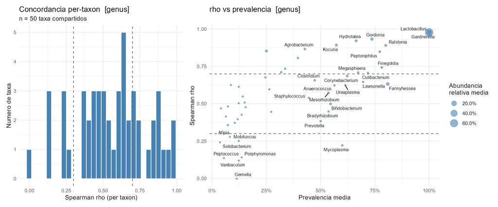

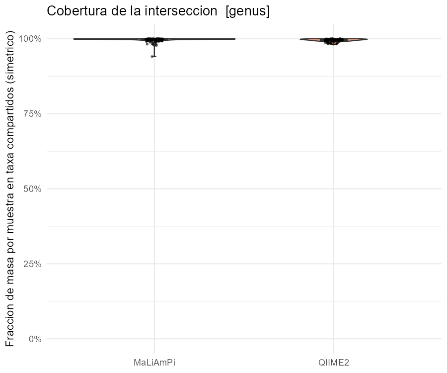

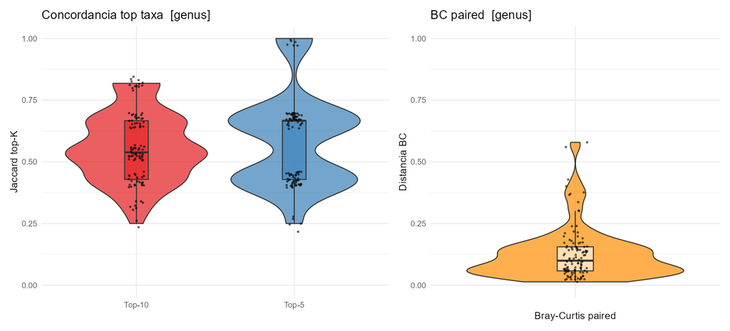

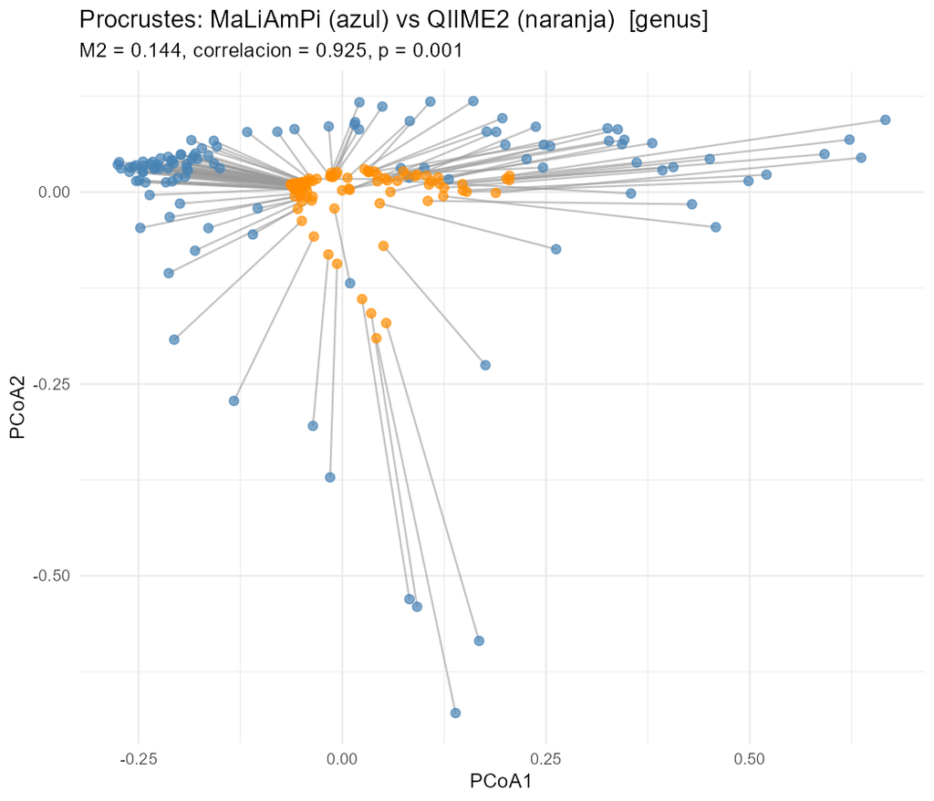

The `all_taxa` figures are in `results/concordance/reproducible/figures/all_taxa/`.

# 6 Reproduction check

## 6.1 Target numbers

The render stops here if any of these differs from the archived report at its three reported decimals.

```r
g <- res_on$genus
targets <- tibble(
  quantity   = c("Median Spearman rho per genus", "Genera with rho > 0.7",
                 "Mantel r", "Procrustes correlation", "Shared genera"),
  archived   = c(0.585, 15, 0.958, 0.925, 65),
  reproduced = c(median(g$per_taxon$rho, na.rm = TRUE), sum(g$per_taxon$rho > 0.7, na.rm = TRUE),
                 g$mantel_res$statistic, g$proc_test$t0, g$n_shared_taxa)
) |>
  mutate(match = round(reproduced, 3) == archived)
knitr::kable(targets, digits = 6)
```

| quantity | archived | reproduced | match |
| --- | --- | --- | --- |
| Median Spearman rho per genus | 0.585 | 0.584732 | TRUE |
| Genera with rho > 0.7 | 15.000 | 15.000000 | TRUE |
| Mantel r | 0.958 | 0.958310 | TRUE |
| Procrustes correlation | 0.925 | 0.925361 | TRUE |
| Shared genera | 65.000 | 65.000000 | TRUE |

```r
stopifnot(all(targets$match))
```

## 6.2 Archived reports, line by line

v3’s report-writing function, unchanged, applied to the results above. Each track’s block is compared with the corresponding block of the archived report: every count, median, IQR and p-value it prints.

```r
bloque_track <- function(r) {
  cov <- r$coverage_df
  mi  <- function(x) sprintf("median = %.3f, IQR [%.3f, %.3f]",
                             median(x), quantile(x, .25), quantile(x, .75))
  c(
    sprintf("- Taxa MaLiAmPi: %d | Taxa QIIME2: %d", r$n_taxa_mal, r$n_taxa_q2),
    sprintf("- Muestras compartidas: %d | Taxa compartidos: %d (directo %d; curado %d)",
            r$n_shared_samples, r$n_shared_taxa, r$n_direct, r$n_curated),
    "",
    "### Cobertura de la interseccion",
    sprintf("- ASIMETRICA  MaLiAmPi: %s", mi(cov$pct_mal_asym)),
    sprintf("- ASIMETRICA  QIIME2:   %s", mi(cov$pct_q2_asym)),
    sprintf("- SIMETRICA   MaLiAmPi: %s", mi(cov$pct_mal_sym)),
    sprintf("- SIMETRICA   QIIME2:   %s", mi(cov$pct_q2_sym)),
    "",
    "### Concordancia per-taxon (Spearman)",
    sprintf("- median rho = %.3f, IQR [%.3f, %.3f] (n = %d evaluables)",
            median(r$per_taxon$rho, na.rm = TRUE),
            quantile(r$per_taxon$rho, .25, na.rm = TRUE),
            quantile(r$per_taxon$rho, .75, na.rm = TRUE),
            sum(!is.na(r$per_taxon$rho))),
    sprintf("- rho > 0.7: %d | rho < 0.3: %d",
            sum(r$per_taxon$rho > 0.7, na.rm = TRUE),
            sum(r$per_taxon$rho < 0.3, na.rm = TRUE)),
    "",
    "### Concordancia per-sample",
    sprintf("- Jaccard top-5:  %s", mi(r$topk_df$j_top5)),
    sprintf("- Jaccard top-10: %s", mi(r$topk_df$j_top10)),
    sprintf("- Bray-Curtis paired: %s", mi(r$bc_paired)),
    "",
    "### Estructura comunitaria (inter-muestra)",
    sprintf("- Mantel r (Spearman): %.3f, p = %.3g", r$mantel_res$statistic, r$mantel_res$signif),
    sprintf("- Procrustes M2: %.3f, correlacion = %.3f, p = %.3g",
            r$proc_test$ss, r$proc_test$t0, r$proc_test$signif),
    ""
  )
}

# The archived block of a track: the lines between its heading and the next one.
bloque_archivado <- function(report, desde, hasta) {
  l <- read_lines(file.path(AS_RUN, report))
  l[(which(l == desde) + 1):(which(l == hasta) - 1)]
}

comparacion <- tribble(
  ~report,                  ~track,     ~res,
  "report_curation_on.md",  "genus",    res_on$genus,
  "report_curation_on.md",  "all_taxa", res_on$all_taxa,
  "report_curation_off.md", "genus",    res_off$genus,
  "report_curation_off.md", "all_taxa", res_off$all_taxa
) |>
  mutate(
    archived = map2(report, track, ~ if (.y == "genus")
      bloque_archivado(.x, "## Generos unicamente", "## Todos los taxa") else
      bloque_archivado(.x, "## Todos los taxa", "## Outputs")),
    reproduced = map(res, bloque_track),
    lines = map_int(archived, ~ sum(nzchar(.x))),
    identical = map2_lgl(archived, reproduced, identical)
  )
knitr::kable(select(comparacion, report, track, `non-empty lines` = lines, identical))
```

| report | track | non-empty lines | identical |
| --- | --- | --- | --- |
| report_curation_on.md | genus | 17 | TRUE |
| report_curation_on.md | all_taxa | 17 | TRUE |
| report_curation_off.md | genus | 17 | TRUE |
| report_curation_off.md | all_taxa | 17 | TRUE |

```r
stopifnot(all(comparacion$identical))
```

## 6.3 Archived files

Every table written above against its archived counterpart, by SHA-256. The two lists of unmatched taxa are also compared as sets, because this port writes them in C-locale order and v3 in the order of the session’s locale. Figures are compared too, for information.

```r
archivos <- c(
  "tables/diag_h1_masa_nongenus_qiime2.csv",
  as.vector(outer(c("spearman_per_taxon.csv", "bray_curtis_per_sample.csv",
                    "topk_jaccard_per_sample.csv", "cobertura_interseccion.csv",
                    "qiime2_taxa_sin_match.txt", "maliampi_taxa_sin_match.txt"),
                  c("genus", "all_taxa"), function(f, t) file.path("tables", t, f))),
  as.vector(outer(c("fig01_spearman_per_taxon.png", "fig02_cobertura_interseccion.png",
                    "fig03_per_sample.png", "fig04_procrustes_pcoa.png"),
                  c("genus", "all_taxa"), function(f, t) file.path("figures", t, f)))
)
check <- tibble(file = archivos) |>
  mutate(
    kind = case_when(str_ends(file, ".png") ~ "figure",
                     str_ends(file, ".txt") ~ "list", TRUE ~ "table"),
    `same bytes` = map_lgl(file, ~ sha256(file.path(AS_RUN, .x)) == sha256(file.path(OUT_DIR, .x))),
    `same set of lines` = map_lgl(file, ~ if (str_ends(.x, ".png")) NA else
      setequal(read_lines(file.path(AS_RUN, .x)), read_lines(file.path(OUT_DIR, .x))))
  )
knitr::kable(check)
```

| file | kind | same bytes | same set of lines |
| --- | --- | --- | --- |
| tables/diag_h1_masa_nongenus_qiime2.csv | table | TRUE | TRUE |
| tables/genus/spearman_per_taxon.csv | table | TRUE | TRUE |
| tables/genus/bray_curtis_per_sample.csv | table | TRUE | TRUE |
| tables/genus/topk_jaccard_per_sample.csv | table | TRUE | TRUE |
| tables/genus/cobertura_interseccion.csv | table | TRUE | TRUE |
| tables/genus/qiime2_taxa_sin_match.txt | list | FALSE | TRUE |
| tables/genus/maliampi_taxa_sin_match.txt | list | TRUE | TRUE |
| tables/all_taxa/spearman_per_taxon.csv | table | TRUE | TRUE |
| tables/all_taxa/bray_curtis_per_sample.csv | table | TRUE | TRUE |
| tables/all_taxa/topk_jaccard_per_sample.csv | table | TRUE | TRUE |
| tables/all_taxa/cobertura_interseccion.csv | table | TRUE | TRUE |
| tables/all_taxa/qiime2_taxa_sin_match.txt | list | FALSE | TRUE |
| tables/all_taxa/maliampi_taxa_sin_match.txt | list | FALSE | TRUE |
| figures/genus/fig01_spearman_per_taxon.png | figure | TRUE | NA |
| figures/genus/fig02_cobertura_interseccion.png | figure | TRUE | NA |
| figures/genus/fig03_per_sample.png | figure | TRUE | NA |
| figures/genus/fig04_procrustes_pcoa.png | figure | TRUE | NA |
| figures/all_taxa/fig01_spearman_per_taxon.png | figure | TRUE | NA |
| figures/all_taxa/fig02_cobertura_interseccion.png | figure | TRUE | NA |
| figures/all_taxa/fig03_per_sample.png | figure | TRUE | NA |
| figures/all_taxa/fig04_procrustes_pcoa.png | figure | TRUE | NA |

```r
stopifnot(all(check$`same bytes`[check$kind == "table"]),
          all(check$`same set of lines`[check$kind == "list"]))
```

[session information not shown]